# Homework 6

2022-05-24

```r
library(tidymodels)
library(ISLR)
library(ISLR2)
```

```r
library(ggplot2)
library(discrim)
library(poissonreg)
library(corrr)
library(klaR) # for naive bayes
tidymodels_prefer()
library(rpart.plot)
library(vip)
library(janitor)
library(randomForest)
library(xgboost)
library(ranger)
```

## Question 1

```r
pokemon_og <- read.csv("~/Downloads/homework-6/data/pokemon.csv")
pokemon <- clean_names(pokemon_og)

classes <- c('Bug', 'Fire', 'Grass', 'Normal', 'Water', 'Psychic')
pokemon <- filter(pokemon, type_1 %in% classes)
pokemon$type_1 <- factor(pokemon$type_1)
pokemon$legendary <- factor(pokemon$legendary)

set.seed(2424)
pokemon_split <- initial_split(pokemon, prop = 0.80,
                                strata = type_1)
pokemon_train <- training(pokemon_split)
pokemon_test <- testing(pokemon_split)
pokemon_folds <- vfold_cv(pokemon_train, v = 5)

pokemon_recipe <- recipe(type_1 ~ ., data = pokemon%>%dplyr::select(type_1,hp:legendary))%>%
  step_dummy(c("legendary", "generation"))%>%
  step_center(all_predictors())%>%
  step_scale(all_predictors())
```

## Question 2

```r
cor_pokemon_train <- pokemon_train %>%
  select(-c(name, type_1, type_2, legendary)) %>%
  correlate()
```

```
##
## Correlation method: 'pearson'
## Missing treated using: 'pairwise.complete.obs'
```

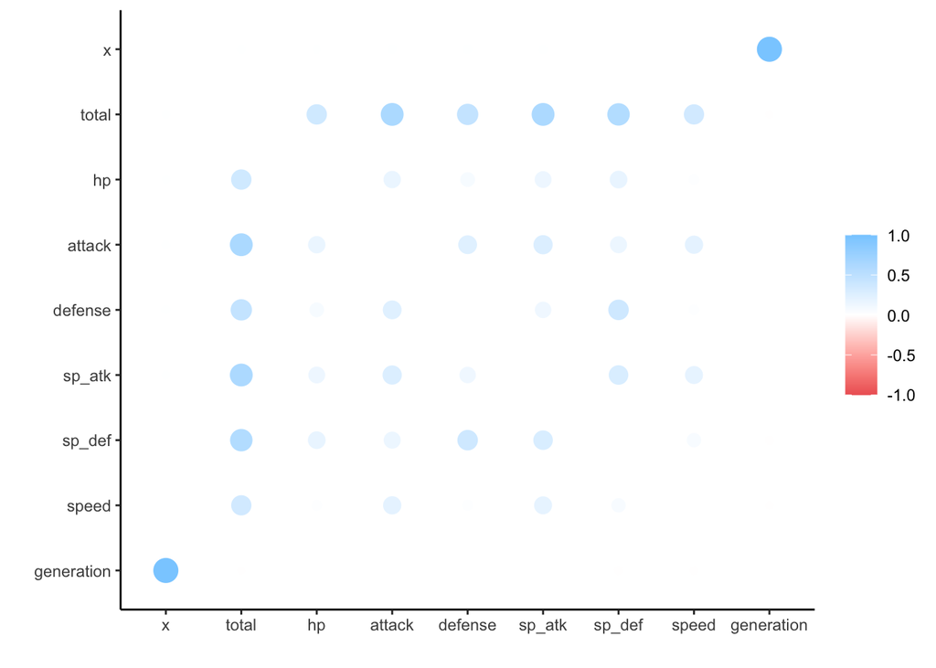

```r
rplot(cor_pokemon_train)
```

For the correlation matrix, I removed all of the non-numeric variables (name, type_1, type_2, and legendary). From the above correlation matrix, we can see that there are multiple positive relationships:

- generation and x
- total to speed, sp_def, sp_atk, defense, attack and hp
- hp to attack, defense, total, sp_atk, and sp_def
- attack to speed, sp_def, sp_atk, defense, hp, and total
- defense to sp_def, sp_atk, attack, hp, and total
- sp_atk to speed, sp_def, defense, attack, hp, and total
- sp_def to sp_atk, defense, attack, hp, and total
- speed to sp_atk, attack and total

## Question 3

```r
tree_spec <- decision_tree() %>%
  set_engine("rpart")

class_tree_spec <- tree_spec %>%
  set_mode("classification")

class_tree_wf <- workflow() %>%
  add_model(class_tree_spec %>% set_args(cost_complexity = tune()))%>%
  add_recipe(pokemon_recipe)

param_grid <- grid_regular(cost_complexity(range = c(-3, -1)), levels = 10)

tune_res <- tune_grid(
  class_tree_wf,
  resamples = pokemon_folds,
  grid = param_grid,
  metrics = metric_set(roc_auc)
)
```

```
## ! Fold1: preprocessor 1/1: The following variables are not factor vectors and wil...
```

```
## ! Fold2: preprocessor 1/1: The following variables are not factor vectors and wil...
```

```
## ! Fold3: preprocessor 1/1: The following variables are not factor vectors and wil...
```

```
## ! Fold4: preprocessor 1/1: The following variables are not factor vectors and wil...
```

```
## ! Fold5: preprocessor 1/1: The following variables are not factor vectors and wil...
```

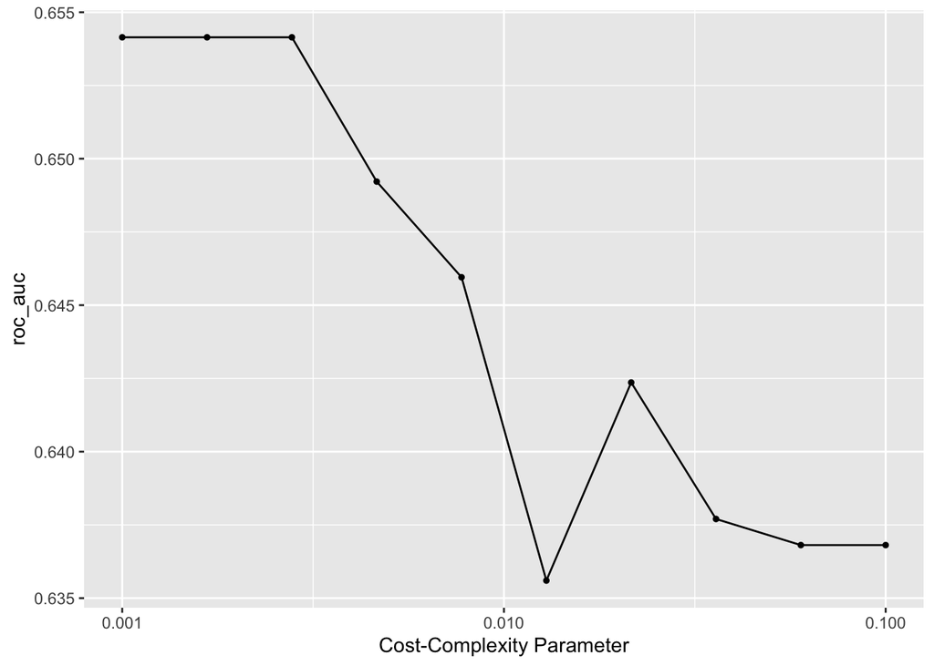

```r
autoplot(tune_res)
```

What do you observe? Does a single decision tree perform better with a smaller or larger complexity penalty? From this, we can see that a single decision tree perfforms better with a smaller complexity penalty.

## Question 4

```r
a <- collect_metrics(tune_res)

arrange(a,cost_complexity)
```

```
## # A tibble: 10 × 7
##    cost_complexity .metric .estimator  mean     n std_err .config
##              <dbl> <chr>   <chr>      <dbl> <int>   <dbl> <chr>
##  1         0.001   roc_auc hand_till  0.654     5 0.0138  Preprocessor1_Model01
##  2         0.00167 roc_auc hand_till  0.654     5 0.0138  Preprocessor1_Model02
##  3         0.00278 roc_auc hand_till  0.654     5 0.0138  Preprocessor1_Model03
##  4         0.00464 roc_auc hand_till  0.649     5 0.0131  Preprocessor1_Model04
##  5         0.00774 roc_auc hand_till  0.646     5 0.0120  Preprocessor1_Model05
##  6         0.0129  roc_auc hand_till  0.636     5 0.00801 Preprocessor1_Model06
##  7         0.0215  roc_auc hand_till  0.642     5 0.00951 Preprocessor1_Model07
##  8         0.0359  roc_auc hand_till  0.638     5 0.00823 Preprocessor1_Model08
##  9         0.0599  roc_auc hand_till  0.637     5 0.00633 Preprocessor1_Model09
## 10         0.1     roc_auc hand_till  0.637     5 0.00633 Preprocessor1_Model10
```

The best roc_auc from the best performing ppruned decision tree on the folds is 0.6541441.

## Question 5

```r
best_complexity <- select_best(tune_res)

class_tree_final <- finalize_workflow(class_tree_wf, best_complexity)

class_tree_final_fit <- fit(class_tree_final, data = pokemon_train)
```

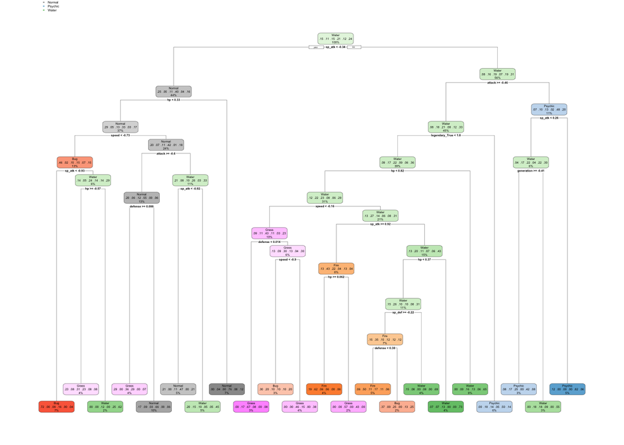

```r
class_tree_final_fit %>%
  extract_fit_engine() %>%
  rpart.plot()
```

```r
pokemon_spec <- rand_forest(mtry = .cols()) %>%
  set_engine("ranger", importance = "impurity") %>%
  set_mode("classification")

pokemon_wf <- workflow() %>%
  add_model(pokemon_spec %>% set_args(mtry = tune()) %>% set_args(trees = tune())  %>% set_args(min_n = tune())) %>%
  add_recipe(pokemon_recipe)

pokemon_fit <- fit(pokemon_spec, type_1 ~ .,
                   data = pokemon_train)
```

- mtry is the number of predictors that will be randomly sampled at each split when creating the tree models.
- tree is the number of trees contained in the ensemble.
- min_n is the minimum number of data points in a node that are required for the node to be split further.

```r
forest_grid <- grid_regular(mtry(range = c(1, 8)), trees(range = c(1, 8)), min_n(range = c(1, 8)), levels = 8)
```

## Question 6

```r
tune_forest_res <- tune_grid(
  pokemon_wf,
  resamples = pokemon_folds,
  grid = forest_grid,
  metrics = metric_set(roc_auc)
)
```

```
## ! Fold1: preprocessor 1/1: The following variables are not factor vectors and wil...
```

```
## ! Fold2: preprocessor 1/1: The following variables are not factor vectors and wil...
```

```
## ! Fold3: preprocessor 1/1: The following variables are not factor vectors and wil...
```

```
## ! Fold4: preprocessor 1/1: The following variables are not factor vectors and wil...
```

```
## ! Fold5: preprocessor 1/1: The following variables are not factor vectors and wil...
```

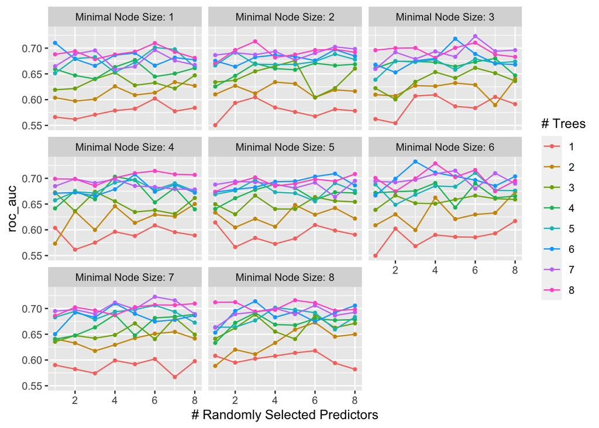

```r
autoplot(tune_forest_res)
```

## Question 7

```r
b <- collect_metrics(tune_forest_res)

arrange(b, mean)
```

```
## # A tibble: 512 × 9
##     mtry trees min_n .metric .estimator  mean     n std_err .config
##    <int> <int> <int> <chr>   <chr>      <dbl> <int>   <dbl> <chr>
##  1     1     1     6 roc_auc hand_till  0.550     5 0.0147  Preprocessor1_Model…
##  2     1     1     2 roc_auc hand_till  0.550     5 0.0268  Preprocessor1_Model…
##  3     2     1     3 roc_auc hand_till  0.554     5 0.0131  Preprocessor1_Model…
##  4     2     1     4 roc_auc hand_till  0.562     5 0.0151  Preprocessor1_Model…
##  5     2     1     1 roc_auc hand_till  0.562     5 0.0109  Preprocessor1_Model…
##  6     1     1     3 roc_auc hand_till  0.562     5 0.0184  Preprocessor1_Model…
##  7     1     1     1 roc_auc hand_till  0.566     5 0.00665 Preprocessor1_Model…
##  8     2     1     5 roc_auc hand_till  0.567     5 0.0150  Preprocessor1_Model…
##  9     7     1     7 roc_auc hand_till  0.567     5 0.0114  Preprocessor1_Model…
## 10     6     1     2 roc_auc hand_till  0.568     5 0.0181  Preprocessor1_Model…
## # … with 502 more rows
```

## Question 8

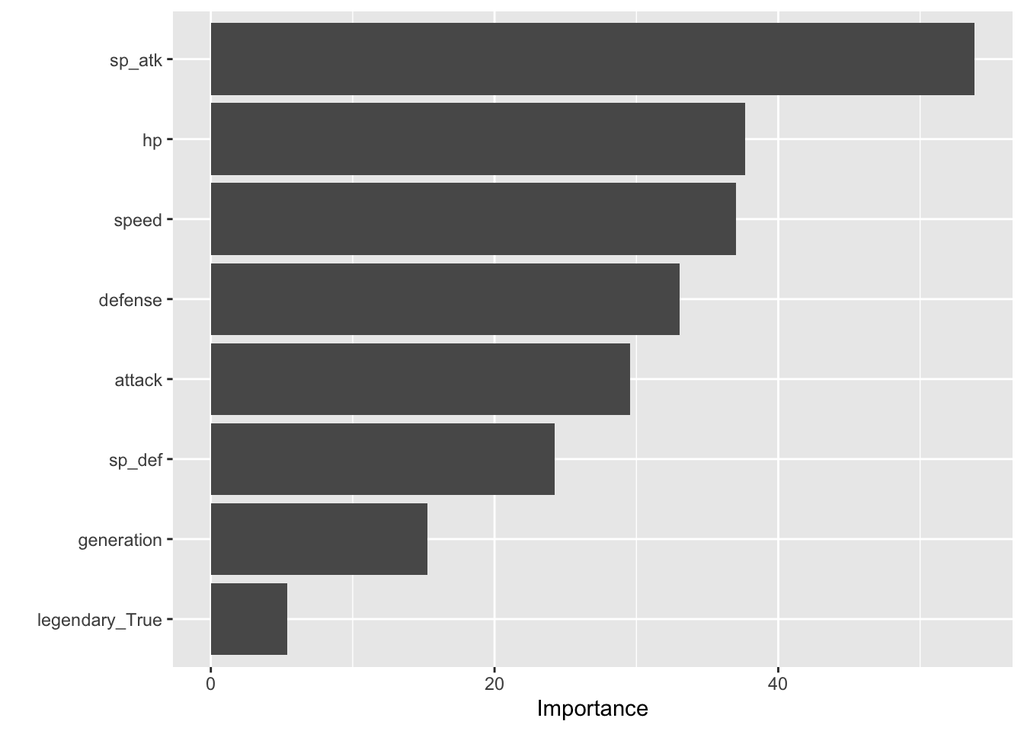

```r
best_for <- select_best(tune_forest_res)

forest_final <- finalize_workflow(pokemon_wf, best_for)

forest_final_fit <- fit(forest_final, data = pokemon_train)
forest_final_fit%>%
  pull_workflow_fit()%>%
  vip()
```

## Question 9

## Question 10